# Risk Factor Analysis

## Outcome Variable

**Outcome Variable:** whz

## Predictor Variables

**Intervention Variable:** predfeed6

**Adjustment Set:**

- arm
- sex
- month
- brthmon
- W_mage
- meducyrs
- feducyrs
- hhwealth_quart
- hfoodsec
- W_mhtcm
- vagbrth
- W_gagebrth
- W_birthwt
- W_birthlen
- W_nrooms
- W_nchldlt5
- W_parity
- impfloor
- impsan
- safeh20
- delta_W_mage
- delta_meducyrs
- delta_feducyrs
- delta_hhwealth_quart
- delta_hfoodsec
- delta_W_mhtcm
- delta_vagbrth
- delta_W_gagebrth
- delta_W_birthwt
- delta_W_birthlen
- delta_W_nrooms
- delta_W_nchldlt5
- delta_W_parity
- delta_impfloor
- delta_impsan
- delta_safeh20

## Stratifying Variables

The analysis was stratified on these variable(s):

- agecat
- studyid
- country

## Data Summary

| agecat | studyid | country | predfeed6 | n_cell | n |
| --- | --- | --- | --- | --- | --- |
| Birth | ki0047075b-MAL-ED | BANGLADESH | 1 | 114 | 219 |
| Birth | ki0047075b-MAL-ED | BANGLADESH | 0 | 105 | 219 |
| Birth | ki0047075b-MAL-ED | BRAZIL | 1 | 26 | 168 |
| Birth | ki0047075b-MAL-ED | BRAZIL | 0 | 142 | 168 |
| Birth | ki0047075b-MAL-ED | INDIA | 1 | 15 | 187 |
| Birth | ki0047075b-MAL-ED | INDIA | 0 | 172 | 187 |
| Birth | ki0047075b-MAL-ED | NEPAL | 1 | 22 | 165 |
| Birth | ki0047075b-MAL-ED | NEPAL | 0 | 143 | 165 |
| Birth | ki0047075b-MAL-ED | PERU | 1 | 104 | 249 |
| Birth | ki0047075b-MAL-ED | PERU | 0 | 145 | 249 |
| Birth | ki0047075b-MAL-ED | SOUTH AFRICA | 1 | 3 | 209 |
| Birth | ki0047075b-MAL-ED | SOUTH AFRICA | 0 | 206 | 209 |
| Birth | ki0047075b-MAL-ED | TANZANIA, UNITED REPUBLIC OF | 1 | 1 | 115 |
| Birth | ki0047075b-MAL-ED | TANZANIA, UNITED REPUBLIC OF | 0 | 114 | 115 |
| Birth | ki1000109-EE | PAKISTAN | 1 | 0 | 1 |
| Birth | ki1000109-EE | PAKISTAN | 0 | 1 | 1 |
| Birth | kiGH5241-JiVitA-3 | BANGLADESH | 1 | 12395 | 15420 |
| Birth | kiGH5241-JiVitA-3 | BANGLADESH | 0 | 3025 | 15420 |
| Birth | kiGH5241-JiVitA-4 | BANGLADESH | 1 | 521 | 633 |
| Birth | kiGH5241-JiVitA-4 | BANGLADESH | 0 | 112 | 633 |
| 6 months | ki0047075b-MAL-ED | BANGLADESH | 1 | 123 | 235 |
| 6 months | ki0047075b-MAL-ED | BANGLADESH | 0 | 112 | 235 |
| 6 months | ki0047075b-MAL-ED | BRAZIL | 1 | 35 | 209 |
| 6 months | ki0047075b-MAL-ED | BRAZIL | 0 | 174 | 209 |
| 6 months | ki0047075b-MAL-ED | INDIA | 1 | 18 | 232 |
| 6 months | ki0047075b-MAL-ED | INDIA | 0 | 214 | 232 |
| 6 months | ki0047075b-MAL-ED | NEPAL | 1 | 29 | 235 |
| 6 months | ki0047075b-MAL-ED | NEPAL | 0 | 206 | 235 |
| 6 months | ki0047075b-MAL-ED | PERU | 1 | 113 | 269 |
| 6 months | ki0047075b-MAL-ED | PERU | 0 | 156 | 269 |
| 6 months | ki0047075b-MAL-ED | SOUTH AFRICA | 1 | 3 | 242 |
| 6 months | ki0047075b-MAL-ED | SOUTH AFRICA | 0 | 239 | 242 |
| 6 months | ki0047075b-MAL-ED | TANZANIA, UNITED REPUBLIC OF | 1 | 2 | 244 |
| 6 months | ki0047075b-MAL-ED | TANZANIA, UNITED REPUBLIC OF | 0 | 242 | 244 |
| 6 months | ki1000109-EE | PAKISTAN | 1 | 220 | 376 |
| 6 months | ki1000109-EE | PAKISTAN | 0 | 156 | 376 |
| 6 months | ki1000304b-SAS-FoodSuppl | INDIA | 1 | 0 | 168 |
| 6 months | ki1000304b-SAS-FoodSuppl | INDIA | 0 | 168 | 168 |
| 6 months | ki1113344-GMS-Nepal | NEPAL | 1 | 404 | 546 |
| 6 months | ki1113344-GMS-Nepal | NEPAL | 0 | 142 | 546 |
| 6 months | ki1148112-LCNI-5 | MALAWI | 1 | 47 | 272 |
| 6 months | ki1148112-LCNI-5 | MALAWI | 0 | 225 | 272 |
| 6 months | kiGH5241-JiVitA-3 | BANGLADESH | 1 | 13186 | 16655 |
| 6 months | kiGH5241-JiVitA-3 | BANGLADESH | 0 | 3469 | 16655 |
| 6 months | kiGH5241-JiVitA-4 | BANGLADESH | 1 | 3331 | 4260 |
| 6 months | kiGH5241-JiVitA-4 | BANGLADESH | 0 | 929 | 4260 |
| 24 months | ki0047075b-MAL-ED | BANGLADESH | 1 | 112 | 209 |
| 24 months | ki0047075b-MAL-ED | BANGLADESH | 0 | 97 | 209 |
| 24 months | ki0047075b-MAL-ED | BRAZIL | 1 | 29 | 169 |
| 24 months | ki0047075b-MAL-ED | BRAZIL | 0 | 140 | 169 |
| 24 months | ki0047075b-MAL-ED | INDIA | 1 | 17 | 224 |
| 24 months | ki0047075b-MAL-ED | INDIA | 0 | 207 | 224 |
| 24 months | ki0047075b-MAL-ED | NEPAL | 1 | 28 | 227 |
| 24 months | ki0047075b-MAL-ED | NEPAL | 0 | 199 | 227 |
| 24 months | ki0047075b-MAL-ED | PERU | 1 | 84 | 198 |
| 24 months | ki0047075b-MAL-ED | PERU | 0 | 114 | 198 |
| 24 months | ki0047075b-MAL-ED | SOUTH AFRICA | 1 | 3 | 227 |
| 24 months | ki0047075b-MAL-ED | SOUTH AFRICA | 0 | 224 | 227 |
| 24 months | ki0047075b-MAL-ED | TANZANIA, UNITED REPUBLIC OF | 1 | 2 | 212 |
| 24 months | ki0047075b-MAL-ED | TANZANIA, UNITED REPUBLIC OF | 0 | 210 | 212 |
| 24 months | ki1113344-GMS-Nepal | NEPAL | 1 | 359 | 479 |
| 24 months | ki1113344-GMS-Nepal | NEPAL | 0 | 120 | 479 |
| 24 months | ki1148112-LCNI-5 | MALAWI | 1 | 34 | 184 |
| 24 months | ki1148112-LCNI-5 | MALAWI | 0 | 150 | 184 |
| 24 months | kiGH5241-JiVitA-3 | BANGLADESH | 1 | 6653 | 8513 |
| 24 months | kiGH5241-JiVitA-3 | BANGLADESH | 0 | 1860 | 8513 |
| 24 months | kiGH5241-JiVitA-4 | BANGLADESH | 1 | 3275 | 4159 |
| 24 months | kiGH5241-JiVitA-4 | BANGLADESH | 0 | 884 | 4159 |

The following strata were considered:

- agecat: 24 months, studyid: ki0047075b-MAL-ED, country: BANGLADESH
- agecat: 24 months, studyid: ki0047075b-MAL-ED, country: BRAZIL
- agecat: 24 months, studyid: ki0047075b-MAL-ED, country: INDIA
- agecat: 24 months, studyid: ki0047075b-MAL-ED, country: NEPAL
- agecat: 24 months, studyid: ki0047075b-MAL-ED, country: PERU
- agecat: 24 months, studyid: ki0047075b-MAL-ED, country: SOUTH AFRICA
- agecat: 24 months, studyid: ki0047075b-MAL-ED, country: TANZANIA, UNITED REPUBLIC OF
- agecat: 24 months, studyid: ki1113344-GMS-Nepal, country: NEPAL
- agecat: 24 months, studyid: ki1148112-LCNI-5, country: MALAWI
- agecat: 24 months, studyid: kiGH5241-JiVitA-3, country: BANGLADESH
- agecat: 24 months, studyid: kiGH5241-JiVitA-4, country: BANGLADESH
- agecat: 6 months, studyid: ki0047075b-MAL-ED, country: BANGLADESH
- agecat: 6 months, studyid: ki0047075b-MAL-ED, country: BRAZIL
- agecat: 6 months, studyid: ki0047075b-MAL-ED, country: INDIA
- agecat: 6 months, studyid: ki0047075b-MAL-ED, country: NEPAL
- agecat: 6 months, studyid: ki0047075b-MAL-ED, country: PERU
- agecat: 6 months, studyid: ki0047075b-MAL-ED, country: SOUTH AFRICA
- agecat: 6 months, studyid: ki0047075b-MAL-ED, country: TANZANIA, UNITED REPUBLIC OF
- agecat: 6 months, studyid: ki1000109-EE, country: PAKISTAN
- agecat: 6 months, studyid: ki1000304b-SAS-FoodSuppl, country: INDIA
- agecat: 6 months, studyid: ki1113344-GMS-Nepal, country: NEPAL
- agecat: 6 months, studyid: ki1148112-LCNI-5, country: MALAWI
- agecat: 6 months, studyid: kiGH5241-JiVitA-3, country: BANGLADESH
- agecat: 6 months, studyid: kiGH5241-JiVitA-4, country: BANGLADESH
- agecat: Birth, studyid: ki0047075b-MAL-ED, country: BANGLADESH
- agecat: Birth, studyid: ki0047075b-MAL-ED, country: BRAZIL
- agecat: Birth, studyid: ki0047075b-MAL-ED, country: INDIA
- agecat: Birth, studyid: ki0047075b-MAL-ED, country: NEPAL
- agecat: Birth, studyid: ki0047075b-MAL-ED, country: PERU
- agecat: Birth, studyid: ki0047075b-MAL-ED, country: SOUTH AFRICA
- agecat: Birth, studyid: ki0047075b-MAL-ED, country: TANZANIA, UNITED REPUBLIC OF
- agecat: Birth, studyid: ki1000109-EE, country: PAKISTAN
- agecat: Birth, studyid: kiGH5241-JiVitA-3, country: BANGLADESH
- agecat: Birth, studyid: kiGH5241-JiVitA-4, country: BANGLADESH

### Dropped Strata

Some strata were dropped due to rare outcomes:

- agecat: Birth, studyid: ki0047075b-MAL-ED, country: SOUTH AFRICA
- agecat: Birth, studyid: ki0047075b-MAL-ED, country: TANZANIA, UNITED REPUBLIC OF
- agecat: Birth, studyid: ki1000109-EE, country: PAKISTAN
- agecat: 6 months, studyid: ki0047075b-MAL-ED, country: SOUTH AFRICA
- agecat: 6 months, studyid: ki0047075b-MAL-ED, country: TANZANIA, UNITED REPUBLIC OF
- agecat: 6 months, studyid: ki1000304b-SAS-FoodSuppl, country: INDIA
- agecat: 24 months, studyid: ki0047075b-MAL-ED, country: SOUTH AFRICA
- agecat: 24 months, studyid: ki0047075b-MAL-ED, country: TANZANIA, UNITED REPUBLIC OF

## Methods Detail

We’re interested in the causal parameters $E[Y_a]$ for all values of $a \in \mathcal{A}$. These parameters represent the mean outcome if, possibly contrary to fact, we intervened to set all units to have $A=a$. Under the randomization and positivity assumptions, these are identified by the statistical parameters $\psi_a=E_W[E_{Y|A,W}(Y|A=a,W)]$. In addition, we’re interested in the mean of $Y$, $E[Y]$ under no intervention (the observed mean). We will estimate these parameters by using SuperLearner to fit the relevant likelihood factors – $E_{Y|A,W}(Y|A=a,W)$ and $p(A=a|W)$, and then updating our likelihood fit using a joint TMLE.

For unadjusted analyses ($W=\{\}$), initial likelihoods were estimated using Lrnr_glm to estimate the simple $E(Y|A)$ and Lrnr_mean to estimate $p(A)$. For adjusted analyses, a small library containing Lrnr_glmnet, Lrnr_xgboost, and Lrnr_mean was used.

Having estimated these parameters, we will then use the delta method to estimate relative risks and attributable risks relative to a prespecified baseline level of $A$.

# Results Detail

## Results Plots

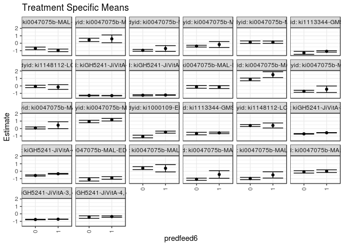

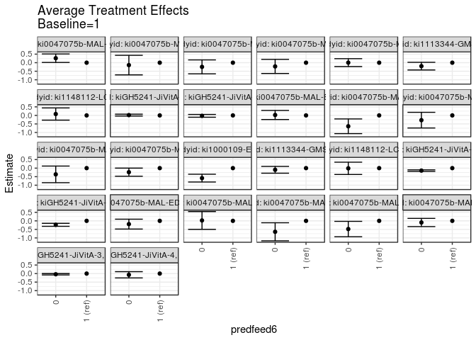

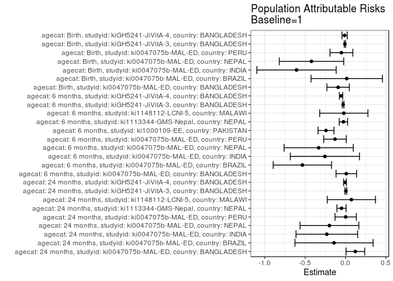

## Results Table

### Parameter: TSM

| agecat | studyid | country | intervention_level | baseline_level | estimate | ci_lower | ci_upper |
| --- | --- | --- | --- | --- | --- | --- | --- |
| Birth | ki0047075b-MAL-ED | BANGLADESH | 1 | NA | -0.9011340 | -1.0759197 | -0.7263484 |
| Birth | ki0047075b-MAL-ED | BANGLADESH | 0 | NA | -1.0924803 | -1.3213997 | -0.8635609 |
| Birth | ki0047075b-MAL-ED | BRAZIL | 1 | NA | 0.3920277 | -0.0962189 | 0.8802742 |
| Birth | ki0047075b-MAL-ED | BRAZIL | 0 | NA | 0.4151162 | 0.2180428 | 0.6121896 |
| Birth | ki0047075b-MAL-ED | INDIA | 1 | NA | -0.4371342 | -0.9435092 | 0.0692408 |
| Birth | ki0047075b-MAL-ED | INDIA | 0 | NA | -1.0774549 | -1.2264223 | -0.9284876 |
| Birth | ki0047075b-MAL-ED | NEPAL | 1 | NA | -0.5014775 | -0.9214113 | -0.0815436 |
| Birth | ki0047075b-MAL-ED | NEPAL | 0 | NA | -0.9812018 | -1.1317262 | -0.8306774 |
| Birth | ki0047075b-MAL-ED | PERU | 1 | NA | 0.0074349 | -0.1723141 | 0.1871838 |
| Birth | ki0047075b-MAL-ED | PERU | 0 | NA | -0.0881271 | -0.2467526 | 0.0704984 |
| Birth | kiGH5241-JiVitA-3 | BANGLADESH | 1 | NA | -0.7157533 | -0.7369945 | -0.6945121 |
| Birth | kiGH5241-JiVitA-3 | BANGLADESH | 0 | NA | -0.7556675 | -0.7950635 | -0.7162716 |
| Birth | kiGH5241-JiVitA-4 | BANGLADESH | 1 | NA | -0.3626518 | -0.4547874 | -0.2705163 |
| Birth | kiGH5241-JiVitA-4 | BANGLADESH | 0 | NA | -0.4344672 | -0.6032800 | -0.2656544 |
| 6 months | ki0047075b-MAL-ED | BANGLADESH | 1 | NA | -0.1562172 | -0.3450510 | 0.0326166 |
| 6 months | ki0047075b-MAL-ED | BANGLADESH | 0 | NA | -0.1311412 | -0.3178827 | 0.0556004 |
| 6 months | ki0047075b-MAL-ED | BRAZIL | 1 | NA | 1.5057701 | 1.1126901 | 1.8988500 |
| 6 months | ki0047075b-MAL-ED | BRAZIL | 0 | NA | 0.8697026 | 0.6920476 | 1.0473576 |
| 6 months | ki0047075b-MAL-ED | INDIA | 1 | NA | -0.4477798 | -0.8863149 | -0.0092447 |
| 6 months | ki0047075b-MAL-ED | INDIA | 0 | NA | -0.7265077 | -0.8583771 | -0.5946384 |
| 6 months | ki0047075b-MAL-ED | NEPAL | 1 | NA | 0.4488970 | -0.0148594 | 0.9126535 |
| 6 months | ki0047075b-MAL-ED | NEPAL | 0 | NA | 0.0843754 | -0.0519302 | 0.2206810 |
| 6 months | ki0047075b-MAL-ED | PERU | 1 | NA | 1.1852989 | 1.0151869 | 1.3554108 |
| 6 months | ki0047075b-MAL-ED | PERU | 0 | NA | 0.9480083 | 0.7802895 | 1.1157271 |
| 6 months | ki1000109-EE | PAKISTAN | 1 | NA | -0.4795880 | -0.6189333 | -0.3402428 |
| 6 months | ki1000109-EE | PAKISTAN | 0 | NA | -1.0639172 | -1.2440017 | -0.8838328 |
| 6 months | ki1113344-GMS-Nepal | NEPAL | 1 | NA | -0.5760176 | -0.6787037 | -0.4733316 |
| 6 months | ki1113344-GMS-Nepal | NEPAL | 0 | NA | -0.6732899 | -0.8426489 | -0.5039309 |
| 6 months | ki1148112-LCNI-5 | MALAWI | 1 | NA | 0.4136901 | 0.0777461 | 0.7496340 |
| 6 months | ki1148112-LCNI-5 | MALAWI | 0 | NA | 0.4028173 | 0.2759186 | 0.5297161 |
| 6 months | kiGH5241-JiVitA-3 | BANGLADESH | 1 | NA | -0.5640901 | -0.5855327 | -0.5426474 |
| 6 months | kiGH5241-JiVitA-3 | BANGLADESH | 0 | NA | -0.7096143 | -0.7509047 | -0.6683238 |
| 6 months | kiGH5241-JiVitA-4 | BANGLADESH | 1 | NA | -0.3421467 | -0.3888283 | -0.2954652 |
| 6 months | kiGH5241-JiVitA-4 | BANGLADESH | 0 | NA | -0.5738907 | -0.6504029 | -0.4973785 |
| 24 months | ki0047075b-MAL-ED | BANGLADESH | 1 | NA | -0.9535249 | -1.1274252 | -0.7796246 |
| 24 months | ki0047075b-MAL-ED | BANGLADESH | 0 | NA | -0.6911346 | -0.8700821 | -0.5121871 |
| 24 months | ki0047075b-MAL-ED | BRAZIL | 1 | NA | 0.5886564 | 0.0656101 | 1.1117027 |
| 24 months | ki0047075b-MAL-ED | BRAZIL | 0 | NA | 0.4472091 | 0.2202103 | 0.6742079 |
| 24 months | ki0047075b-MAL-ED | INDIA | 1 | NA | -0.7077079 | -1.0964594 | -0.3189565 |
| 24 months | ki0047075b-MAL-ED | INDIA | 0 | NA | -0.9530704 | -1.0751538 | -0.8309870 |
| 24 months | ki0047075b-MAL-ED | NEPAL | 1 | NA | -0.1714563 | -0.5659807 | 0.2230681 |
| 24 months | ki0047075b-MAL-ED | NEPAL | 0 | NA | -0.3906561 | -0.5083707 | -0.2729416 |
| 24 months | ki0047075b-MAL-ED | PERU | 1 | NA | 0.1407477 | -0.0147979 | 0.2962934 |
| 24 months | ki0047075b-MAL-ED | PERU | 0 | NA | 0.1438080 | -0.0262040 | 0.3138199 |
| 24 months | ki1113344-GMS-Nepal | NEPAL | 1 | NA | -1.0872051 | -1.1866316 | -0.9877785 |
| 24 months | ki1113344-GMS-Nepal | NEPAL | 0 | NA | -1.2899520 | -1.4914353 | -1.0884688 |
| 24 months | ki1148112-LCNI-5 | MALAWI | 1 | NA | -0.1497378 | -0.4681787 | 0.1687030 |
| 24 months | ki1148112-LCNI-5 | MALAWI | 0 | NA | -0.0691656 | -0.2288955 | 0.0905642 |
| 24 months | kiGH5241-JiVitA-3 | BANGLADESH | 1 | NA | -1.3036345 | -1.3300093 | -1.2772598 |
| 24 months | kiGH5241-JiVitA-3 | BANGLADESH | 0 | NA | -1.2860285 | -1.3339493 | -1.2381078 |
| 24 months | kiGH5241-JiVitA-4 | BANGLADESH | 1 | NA | -1.2277055 | -1.2645363 | -1.1908747 |
| 24 months | kiGH5241-JiVitA-4 | BANGLADESH | 0 | NA | -1.2533861 | -1.3289215 | -1.1778508 |

### Parameter: E(Y)

| agecat | studyid | country | intervention_level | baseline_level | estimate | ci_lower | ci_upper |
| --- | --- | --- | --- | --- | --- | --- | --- |
| Birth | ki0047075b-MAL-ED | BANGLADESH | NA | NA | -0.9925114 | -1.1346572 | -0.8503656 |
| Birth | ki0047075b-MAL-ED | BRAZIL | NA | NA | 0.4073214 | 0.2229599 | 0.5916830 |
| Birth | ki0047075b-MAL-ED | INDIA | NA | NA | -1.0435829 | -1.1865715 | -0.9005943 |
| Birth | ki0047075b-MAL-ED | NEPAL | NA | NA | -0.9226061 | -1.0630064 | -0.7822058 |
| Birth | ki0047075b-MAL-ED | PERU | NA | NA | -0.0430924 | -0.1600210 | 0.0738362 |
| Birth | kiGH5241-JiVitA-3 | BANGLADESH | NA | NA | -0.7234060 | -0.7433920 | -0.7034200 |
| Birth | kiGH5241-JiVitA-4 | BANGLADESH | NA | NA | -0.3738863 | -0.4580087 | -0.2897638 |
| 6 months | ki0047075b-MAL-ED | BANGLADESH | NA | NA | -0.1464929 | -0.2779745 | -0.0150113 |
| 6 months | ki0047075b-MAL-ED | BRAZIL | NA | NA | 0.9717225 | 0.8073791 | 1.1360658 |
| 6 months | ki0047075b-MAL-ED | INDIA | NA | NA | -0.7028736 | -0.8283047 | -0.5774424 |
| 6 months | ki0047075b-MAL-ED | NEPAL | NA | NA | 0.1167518 | -0.0146454 | 0.2481490 |
| 6 months | ki0047075b-MAL-ED | PERU | NA | NA | 1.0554461 | 0.9322755 | 1.1786167 |
| 6 months | ki1000109-EE | PAKISTAN | NA | NA | -0.7212766 | -0.8346857 | -0.6078675 |
| 6 months | ki1113344-GMS-Nepal | NEPAL | NA | NA | -0.6015049 | -0.6892785 | -0.5137313 |
| 6 months | ki1148112-LCNI-5 | MALAWI | NA | NA | 0.3927574 | 0.2737700 | 0.5117448 |
| 6 months | kiGH5241-JiVitA-3 | BANGLADESH | NA | NA | -0.5931801 | -0.6126929 | -0.5736674 |
| 6 months | kiGH5241-JiVitA-4 | BANGLADESH | NA | NA | -0.3971948 | -0.4378192 | -0.3565704 |
| 24 months | ki0047075b-MAL-ED | BANGLADESH | NA | NA | -0.8315789 | -0.9546058 | -0.7085521 |
| 24 months | ki0047075b-MAL-ED | BRAZIL | NA | NA | 0.4466272 | 0.2416144 | 0.6516401 |
| 24 months | ki0047075b-MAL-ED | INDIA | NA | NA | -0.9390848 | -1.0545919 | -0.8235777 |
| 24 months | ki0047075b-MAL-ED | NEPAL | NA | NA | -0.3703084 | -0.4835704 | -0.2570464 |
| 24 months | ki0047075b-MAL-ED | PERU | NA | NA | 0.1430051 | 0.0254144 | 0.2605957 |
| 24 months | ki1113344-GMS-Nepal | NEPAL | NA | NA | -1.1369520 | -1.2269975 | -1.0469065 |
| 24 months | ki1148112-LCNI-5 | MALAWI | NA | NA | -0.0771196 | -0.2204715 | 0.0662323 |
| 24 months | kiGH5241-JiVitA-3 | BANGLADESH | NA | NA | -1.2991319 | -1.3225545 | -1.2757094 |
| 24 months | kiGH5241-JiVitA-4 | BANGLADESH | NA | NA | -1.2337581 | -1.2679680 | -1.1995482 |

### Parameter: ATE

| agecat | studyid | country | intervention_level | baseline_level | estimate | ci_lower | ci_upper |
| --- | --- | --- | --- | --- | --- | --- | --- |
| Birth | ki0047075b-MAL-ED | BANGLADESH | 1 | 1 | 0.0000000 | 0.0000000 | 0.0000000 |
| Birth | ki0047075b-MAL-ED | BANGLADESH | 0 | 1 | -0.1913463 | -0.4805779 | 0.0978854 |
| Birth | ki0047075b-MAL-ED | BRAZIL | 1 | 1 | 0.0000000 | 0.0000000 | 0.0000000 |
| Birth | ki0047075b-MAL-ED | BRAZIL | 0 | 1 | 0.0230885 | -0.4978566 | 0.5440336 |
| Birth | ki0047075b-MAL-ED | INDIA | 1 | 1 | 0.0000000 | 0.0000000 | 0.0000000 |
| Birth | ki0047075b-MAL-ED | INDIA | 0 | 1 | -0.6403208 | -1.1684829 | -0.1121587 |
| Birth | ki0047075b-MAL-ED | NEPAL | 1 | 1 | 0.0000000 | 0.0000000 | 0.0000000 |
| Birth | ki0047075b-MAL-ED | NEPAL | 0 | 1 | -0.4797243 | -0.9299090 | -0.0295397 |
| Birth | ki0047075b-MAL-ED | PERU | 1 | 1 | 0.0000000 | 0.0000000 | 0.0000000 |
| Birth | ki0047075b-MAL-ED | PERU | 0 | 1 | -0.0955620 | -0.3356839 | 0.1445600 |
| Birth | kiGH5241-JiVitA-3 | BANGLADESH | 1 | 1 | 0.0000000 | 0.0000000 | 0.0000000 |
| Birth | kiGH5241-JiVitA-3 | BANGLADESH | 0 | 1 | -0.0399142 | -0.0806874 | 0.0008590 |
| Birth | kiGH5241-JiVitA-4 | BANGLADESH | 1 | 1 | 0.0000000 | 0.0000000 | 0.0000000 |
| Birth | kiGH5241-JiVitA-4 | BANGLADESH | 0 | 1 | -0.0718153 | -0.2553114 | 0.1116807 |
| 6 months | ki0047075b-MAL-ED | BANGLADESH | 1 | 1 | 0.0000000 | 0.0000000 | 0.0000000 |
| 6 months | ki0047075b-MAL-ED | BANGLADESH | 0 | 1 | 0.0250760 | -0.2411999 | 0.2913520 |
| 6 months | ki0047075b-MAL-ED | BRAZIL | 1 | 1 | 0.0000000 | 0.0000000 | 0.0000000 |
| 6 months | ki0047075b-MAL-ED | BRAZIL | 0 | 1 | -0.6360675 | -1.0658111 | -0.2063239 |
| 6 months | ki0047075b-MAL-ED | INDIA | 1 | 1 | 0.0000000 | 0.0000000 | 0.0000000 |
| 6 months | ki0047075b-MAL-ED | INDIA | 0 | 1 | -0.2787279 | -0.7375829 | 0.1801270 |
| 6 months | ki0047075b-MAL-ED | NEPAL | 1 | 1 | 0.0000000 | 0.0000000 | 0.0000000 |
| 6 months | ki0047075b-MAL-ED | NEPAL | 0 | 1 | -0.3645216 | -0.8507993 | 0.1217561 |
| 6 months | ki0047075b-MAL-ED | PERU | 1 | 1 | 0.0000000 | 0.0000000 | 0.0000000 |
| 6 months | ki0047075b-MAL-ED | PERU | 0 | 1 | -0.2372906 | -0.4759821 | 0.0014010 |
| 6 months | ki1000109-EE | PAKISTAN | 1 | 1 | 0.0000000 | 0.0000000 | 0.0000000 |
| 6 months | ki1000109-EE | PAKISTAN | 0 | 1 | -0.5843292 | -0.8124177 | -0.3562407 |
| 6 months | ki1113344-GMS-Nepal | NEPAL | 1 | 1 | 0.0000000 | 0.0000000 | 0.0000000 |
| 6 months | ki1113344-GMS-Nepal | NEPAL | 0 | 1 | -0.0972723 | -0.2955412 | 0.1009966 |
| 6 months | ki1148112-LCNI-5 | MALAWI | 1 | 1 | 0.0000000 | 0.0000000 | 0.0000000 |
| 6 months | ki1148112-LCNI-5 | MALAWI | 0 | 1 | -0.0108727 | -0.3701807 | 0.3484352 |
| 6 months | kiGH5241-JiVitA-3 | BANGLADESH | 1 | 1 | 0.0000000 | 0.0000000 | 0.0000000 |
| 6 months | kiGH5241-JiVitA-3 | BANGLADESH | 0 | 1 | -0.1455242 | -0.1903702 | -0.1006783 |
| 6 months | kiGH5241-JiVitA-4 | BANGLADESH | 1 | 1 | 0.0000000 | 0.0000000 | 0.0000000 |
| 6 months | kiGH5241-JiVitA-4 | BANGLADESH | 0 | 1 | -0.2317440 | -0.3195380 | -0.1439501 |
| 24 months | ki0047075b-MAL-ED | BANGLADESH | 1 | 1 | 0.0000000 | 0.0000000 | 0.0000000 |
| 24 months | ki0047075b-MAL-ED | BANGLADESH | 0 | 1 | 0.2623903 | 0.0136091 | 0.5111716 |
| 24 months | ki0047075b-MAL-ED | BRAZIL | 1 | 1 | 0.0000000 | 0.0000000 | 0.0000000 |
| 24 months | ki0047075b-MAL-ED | BRAZIL | 0 | 1 | -0.1414472 | -0.7142356 | 0.4313411 |
| 24 months | ki0047075b-MAL-ED | INDIA | 1 | 1 | 0.0000000 | 0.0000000 | 0.0000000 |
| 24 months | ki0047075b-MAL-ED | INDIA | 0 | 1 | -0.2453624 | -0.6528832 | 0.1621584 |
| 24 months | ki0047075b-MAL-ED | NEPAL | 1 | 1 | 0.0000000 | 0.0000000 | 0.0000000 |
| 24 months | ki0047075b-MAL-ED | NEPAL | 0 | 1 | -0.2191998 | -0.6312629 | 0.1928632 |
| 24 months | ki0047075b-MAL-ED | PERU | 1 | 1 | 0.0000000 | 0.0000000 | 0.0000000 |
| 24 months | ki0047075b-MAL-ED | PERU | 0 | 1 | 0.0030602 | -0.2278731 | 0.2339936 |
| 24 months | ki1113344-GMS-Nepal | NEPAL | 1 | 1 | 0.0000000 | 0.0000000 | 0.0000000 |
| 24 months | ki1113344-GMS-Nepal | NEPAL | 0 | 1 | -0.2027470 | -0.4276356 | 0.0221416 |
| 24 months | ki1148112-LCNI-5 | MALAWI | 1 | 1 | 0.0000000 | 0.0000000 | 0.0000000 |
| 24 months | ki1148112-LCNI-5 | MALAWI | 0 | 1 | 0.0805722 | -0.2770117 | 0.4381562 |
| 24 months | kiGH5241-JiVitA-3 | BANGLADESH | 1 | 1 | 0.0000000 | 0.0000000 | 0.0000000 |
| 24 months | kiGH5241-JiVitA-3 | BANGLADESH | 0 | 1 | 0.0176060 | -0.0360074 | 0.0712194 |
| 24 months | kiGH5241-JiVitA-4 | BANGLADESH | 1 | 1 | 0.0000000 | 0.0000000 | 0.0000000 |
| 24 months | kiGH5241-JiVitA-4 | BANGLADESH | 0 | 1 | -0.0256806 | -0.1073578 | 0.0559965 |

### Parameter: PAR

| agecat | studyid | country | intervention_level | baseline_level | estimate | ci_lower | ci_upper |
| --- | --- | --- | --- | --- | --- | --- | --- |
| Birth | ki0047075b-MAL-ED | BANGLADESH | 1 | NA | -0.0913774 | -0.2303749 | 0.0476202 |
| Birth | ki0047075b-MAL-ED | BRAZIL | 1 | NA | 0.0152938 | -0.4269493 | 0.4575369 |
| Birth | ki0047075b-MAL-ED | INDIA | 1 | NA | -0.6064487 | -1.0973710 | -0.1155265 |
| Birth | ki0047075b-MAL-ED | NEPAL | 1 | NA | -0.4211286 | -0.8199975 | -0.0222597 |
| Birth | ki0047075b-MAL-ED | PERU | 1 | NA | -0.0505272 | -0.1920838 | 0.0910293 |
| Birth | kiGH5241-JiVitA-3 | BANGLADESH | 1 | NA | -0.0076527 | -0.0156956 | 0.0003903 |
| Birth | kiGH5241-JiVitA-4 | BANGLADESH | 1 | NA | -0.0112344 | -0.0436630 | 0.0211942 |
| 6 months | ki0047075b-MAL-ED | BANGLADESH | 1 | NA | 0.0097243 | -0.1173788 | 0.1368274 |
| 6 months | ki0047075b-MAL-ED | BRAZIL | 1 | NA | -0.5340476 | -0.8953497 | -0.1727454 |
| 6 months | ki0047075b-MAL-ED | INDIA | 1 | NA | -0.2550937 | -0.6831241 | 0.1729366 |
| 6 months | ki0047075b-MAL-ED | NEPAL | 1 | NA | -0.3321452 | -0.7607448 | 0.0964543 |
| 6 months | ki0047075b-MAL-ED | PERU | 1 | NA | -0.1298528 | -0.2699269 | 0.0102214 |
| 6 months | ki1000109-EE | PAKISTAN | 1 | NA | -0.2416886 | -0.3407583 | -0.1426189 |
| 6 months | ki1113344-GMS-Nepal | NEPAL | 1 | NA | -0.0254873 | -0.0771680 | 0.0261935 |
| 6 months | ki1148112-LCNI-5 | MALAWI | 1 | NA | -0.0209327 | -0.3196579 | 0.2777924 |
| 6 months | kiGH5241-JiVitA-3 | BANGLADESH | 1 | NA | -0.0290900 | -0.0386063 | -0.0195738 |
| 6 months | kiGH5241-JiVitA-4 | BANGLADESH | 1 | NA | -0.0550481 | -0.0752486 | -0.0348476 |
| 24 months | ki0047075b-MAL-ED | BANGLADESH | 1 | NA | 0.1219460 | 0.0066087 | 0.2372832 |
| 24 months | ki0047075b-MAL-ED | BRAZIL | 1 | NA | -0.1420292 | -0.6257539 | 0.3416955 |
| 24 months | ki0047075b-MAL-ED | INDIA | 1 | NA | -0.2313769 | -0.6129473 | 0.1501935 |
| 24 months | ki0047075b-MAL-ED | NEPAL | 1 | NA | -0.1988521 | -0.5627409 | 0.1650367 |
| 24 months | ki0047075b-MAL-ED | PERU | 1 | NA | 0.0022573 | -0.1302017 | 0.1347163 |
| 24 months | ki1113344-GMS-Nepal | NEPAL | 1 | NA | -0.0497469 | -0.1064027 | 0.0069089 |
| 24 months | ki1148112-LCNI-5 | MALAWI | 1 | NA | 0.0726183 | -0.2262295 | 0.3714660 |
| 24 months | kiGH5241-JiVitA-3 | BANGLADESH | 1 | NA | 0.0045026 | -0.0071562 | 0.0161615 |
| 24 months | kiGH5241-JiVitA-4 | BANGLADESH | 1 | NA | -0.0060526 | -0.0236521 | 0.0115469 |